# RR_Data_Analysis

Rupender Raj

9/23/2020

## Github Repositories :

```
            https://github.com/rupenders/Reproducible_research_Cousera_ASS1
```

## Inroduction :

This assignment makes use of data from a personal activity monitoring device. This device collects data at 5 minute intervals through out the day. The data consists of two months of data from an anonymous individual collected during the months of October and November, 2012 and include the number of steps taken in 5 minute intervals each day.

The variables included in this data set are:

- Steps : Number of steps taking in a 5-minute interval (missing values are coded as NA).
- date : The date on which the measurement was taken in YYYY-MM-DD format.
- interval: Identifier for the 5-minute interval in which measurement was taken.

## Commit containing full submission

1.Code for reading in the dataset and/or processing the data  
2.Histogram of the total number of steps taken each day  
3.Mean and median number of steps taken each day  
4.Time series plot of the average number of steps taken  
5.The 5-minute interval that, on average, contains the maximum number of steps  
6.Code to describe and show a strategy for imputing missing data  
7.Histogram of the total number of steps taken each day after missing values are imputed  
8.Panel plot comparing the average number of steps taken per 5-minute interval across weekdays and weekends  
9.All of the R code needed to reproduce the results (numbers, plots, etc.) in the report

## Link to the Data Set

```
            https://d396qusza40orc.cloudfront.net/repdata%2Fdata%2Factivity.zip
```

# Load Libaray

```r
library(data.table)
library(dplyr)
library(ggplot2)
library(xtable)
```

# 1. Download, unzip and load the data

```r
dir_d <- getwd()
url <- "https://d396qusza40orc.cloudfront.net/repdata%2Fdata%2Factivity.zip"
download.file(url, file.path(dir_d, "dataFiles.zip"))
unzip(zipfile = "dataFiles.zip")
acti_data <- data.table::fread("activity.csv")
head(acti_data)
```

```
##    steps       date interval
## 1:    NA 2012-10-01        0
## 2:    NA 2012-10-01        5
## 3:    NA 2012-10-01       10
## 4:    NA 2012-10-01       15
## 5:    NA 2012-10-01       20
## 6:    NA 2012-10-01       25
```

# 2. Total number of steps taken each date

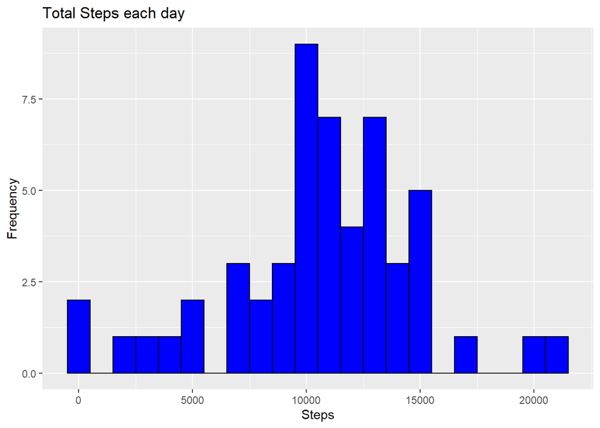

```r
data_sub <-acti_data %>% select(steps,date) %>% filter(steps != "NA") %>%
        group_by(date) %>% summarize(Total_steps = sum(steps))

ggplot(data_sub, aes(x = Total_steps)) +
    geom_histogram(color ="black", fill = "blue", binwidth = 1000) +
    labs(title = "Total Steps each day", x = "Steps", y = "Frequency")
```